# Image Processing with Python

Jacob Deppen and David Palmquist

July, 2023

# Thank you!

Thanks to Nisha and Mary for hosting and thank *you* for coming.

# Presenters

- Jacob Deppen, `deppen8` on GitHub
- David Palmquist, `quist00` on GitHub

# Acknowledgements

- Current maintainer team: Kimberly Meechan, Ulf Schiller, Robert Turner, Toby Hodges
- Content originally developed by Mark Meysenburg, Tessa Durham Brooks, Dominik Kutra, Constantin Pape, and Erin Becker.
- Many community members have opened issues and pull requests to improve the lesson.

# Image Processing is stable!

Moved from “beta” to “stable” in January 2023.

[figure not shown]

Four stages of lesson release timeline

# Why teach this lesson?

- Images are everywhere.
- Image data is different to tabular / data frame data.

# What’s in the lesson?

- Introduction to images in research.
- How images are represented by computers.
- Software tools for working with images.
- Manipulating images using software.
- Extracting data / statistics from images.

# How do we think about image data?

Magritte’s “La Trahison des Images” (“The Treachery of Images”) (1928-9) or “Ceci n’est pas une pipe” (“This is not a pipe”).

# Key concepts

- Pixels
- Arrays
- Coordinates
- Channels
- Kernels
- Binary masks

# What’s not in the lesson?

- AI / Deep Learning

Lesson is a more “traditional” approach: easier to explain results, less data-intensive, applicable to more domains.

# What do I need to know?

- Bash shell skills
  - Navigating directories using `pwd`, `ls`, `cd <subdirectory>`, and `cd ..`, Run a Python script from the command line.
- Python skills
  - Variables and types, lists, logic (`if`, `else`, etc.), basic file input / output

# Lesson setup

- Data
  - Download from FigShare
- Software
  - Anaconda (base environment includes all required packages) and Jupyter Notebooks

# Introduction to image processing

- What research questions can we answer with image processing?
  - [imaging a Black Hole](https://iopscience.iop.org/article/10.3847/2041-8213/ab0e85)
  - [estimating the population of Emperor Penguins](https://www.ncbi.nlm.nih.gov/pmc/articles/PMC3325796/),
  - the global-scale analysis of marine plankton diversity,
  - [segmentation of liver and vessels from CT images](https://doi.org/10.1016/j.cmpb.2017.12.008)
- Morphometrics, also known as “measuring things in images”.

# Optional breakout 1

- What research areas do you expect your learners to come from?
- Are there particular challenges in working with image data in these areas?

# Image basics

- Representation of images in computers.
- Images, arrays and pixels.
- How RGB is used to make colour images.
- File formats and compression.

# If you are a computer, images are arrays

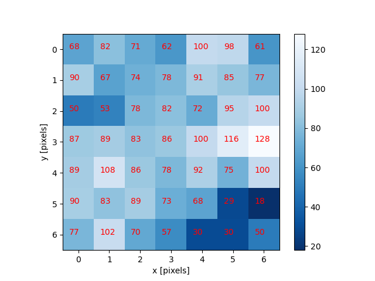

Image with pixel values overlaid

# Image representation

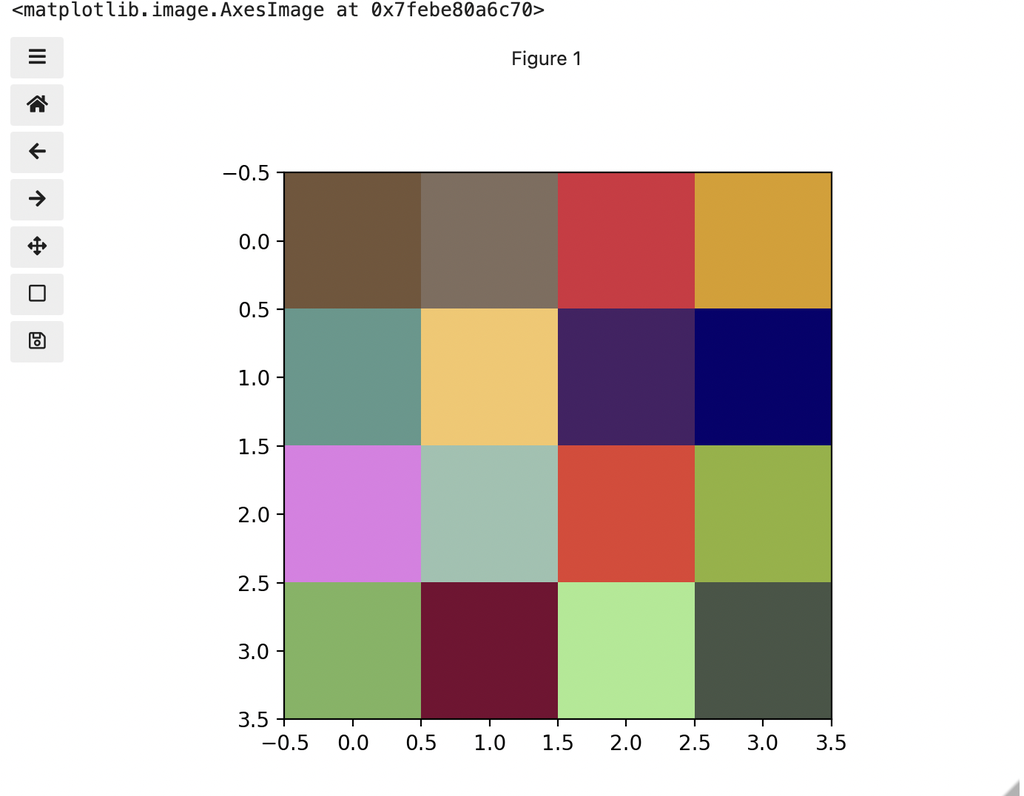

RGB Image

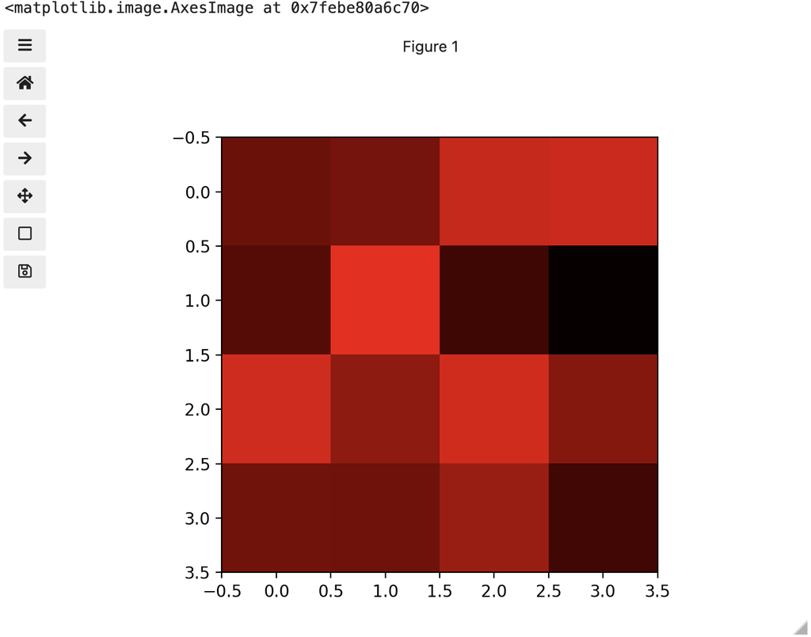

Red channel

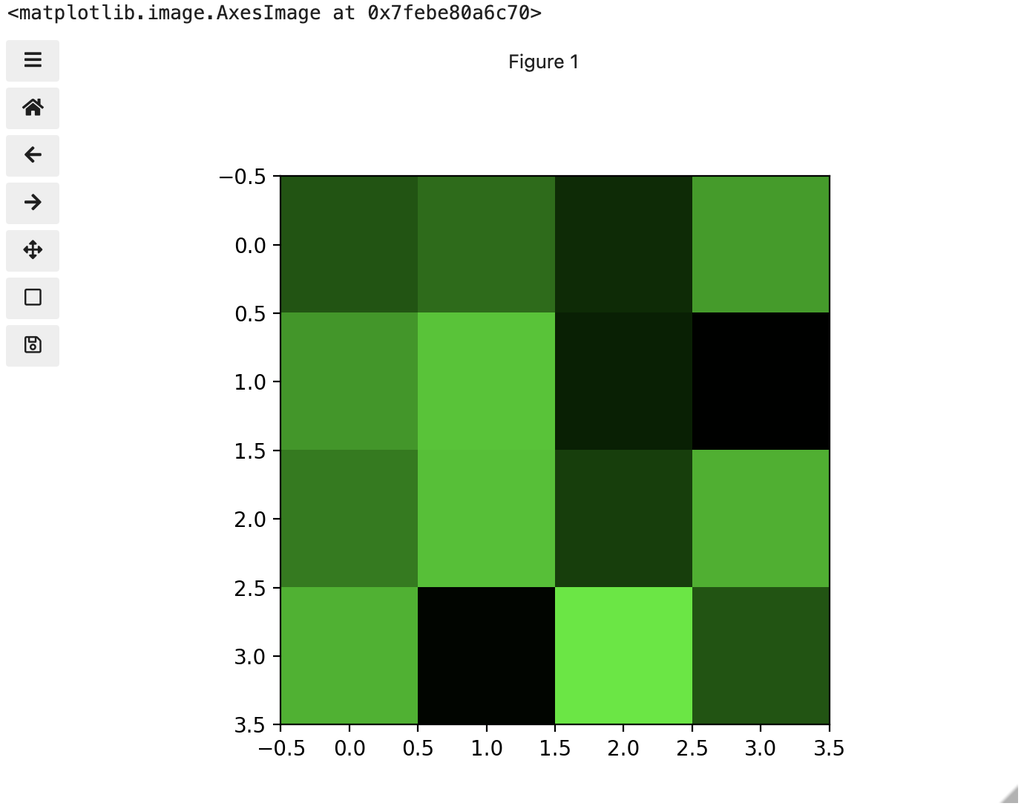

Green channel

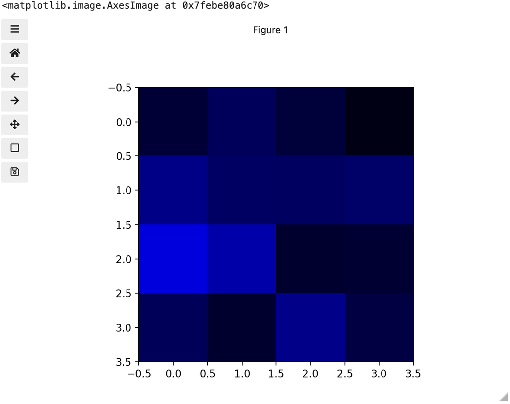

Blue channel

# Tools for working with images

- `skimage` (scikit-image)
  - Do weird things with arrays (e.g. `skimage.transform.resize`).
- `numpy`
  - Conventional array stuff (e.g. sub-setting, find all values `> x`).
- `imageio`
  - Input + output; images are often *not* stored in `numpy` friendly formats.

# Analyzing images

The distribution of intensity of colour in an image can tell us things.

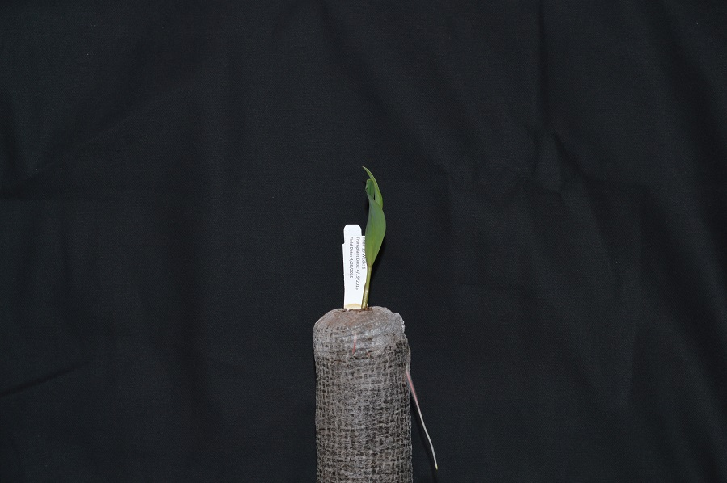

Plant Seedling

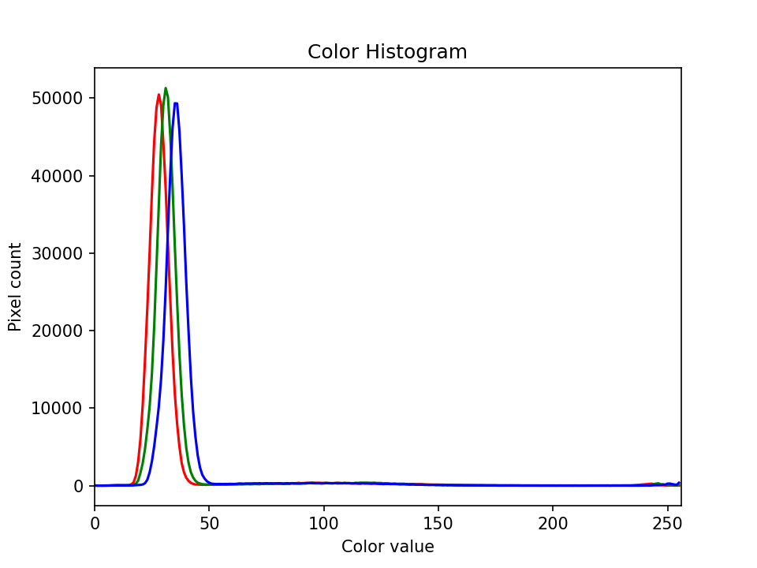

Histogram

# Blurring

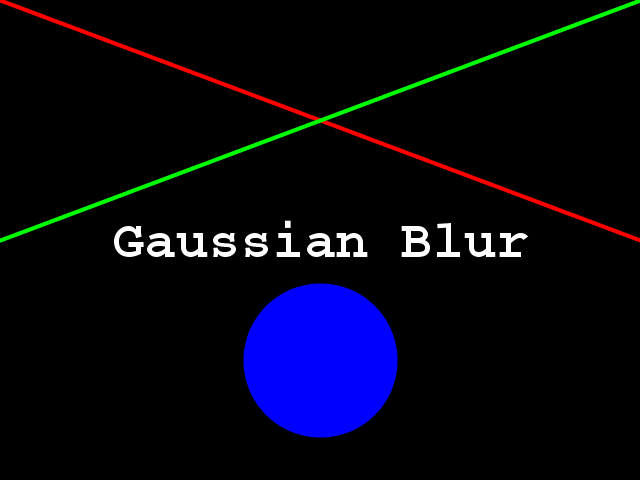

Original

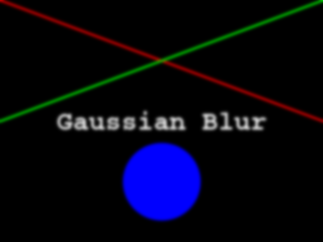

Blurred

# Thresholding

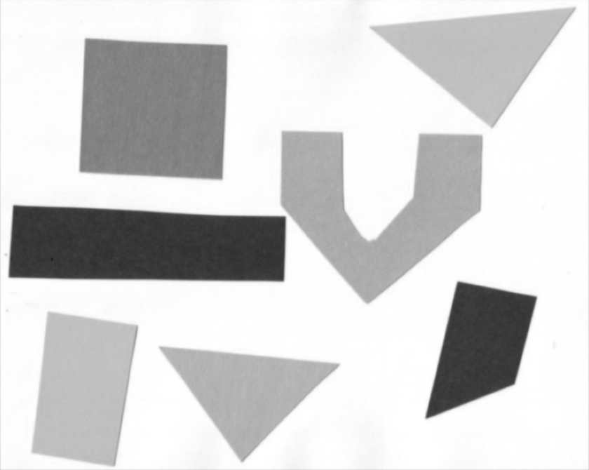

Blurred grayscale

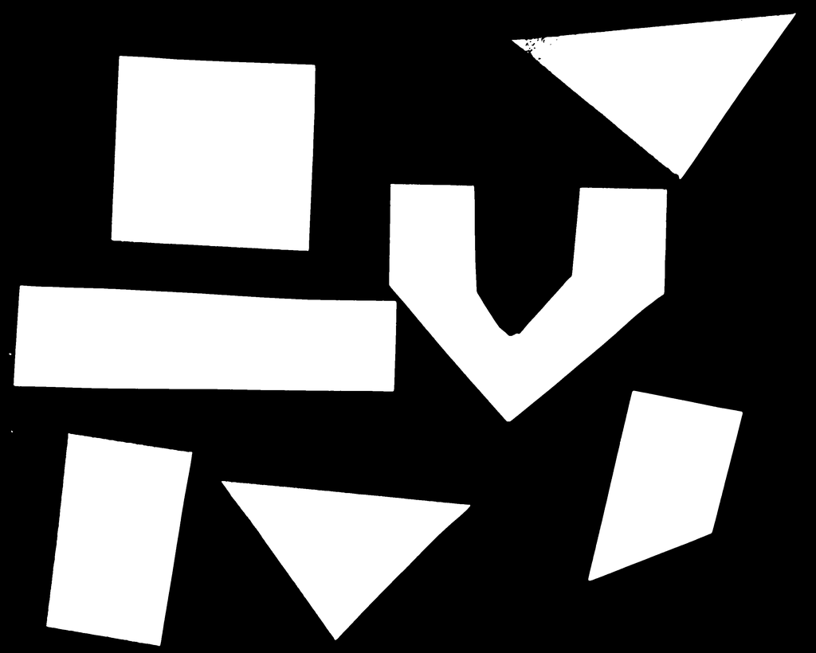

Threshold applied

# Connected components

Separating objects and getting information about them.

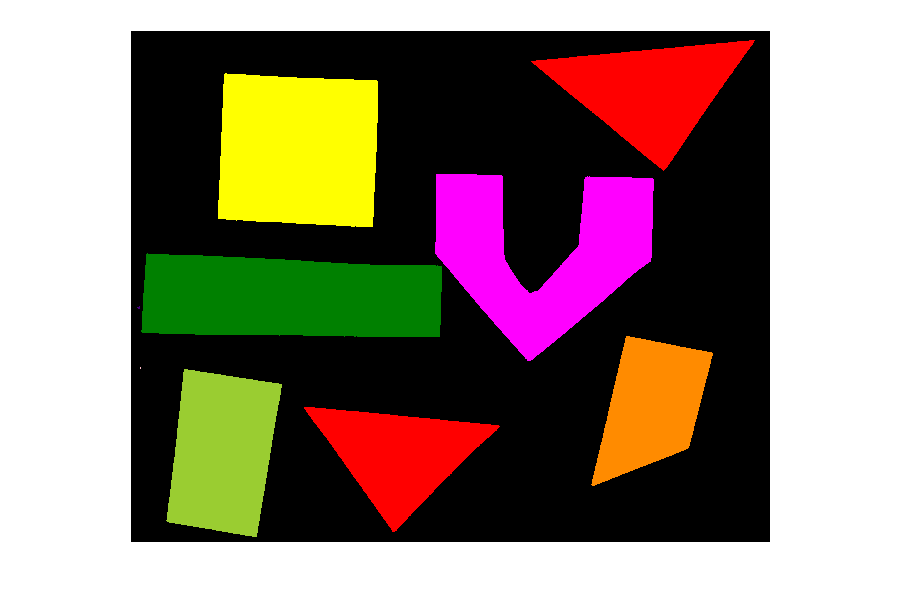

Labelled shapes

# Getting statistics

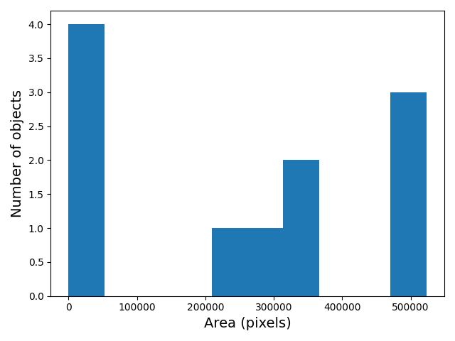

Areas histogram

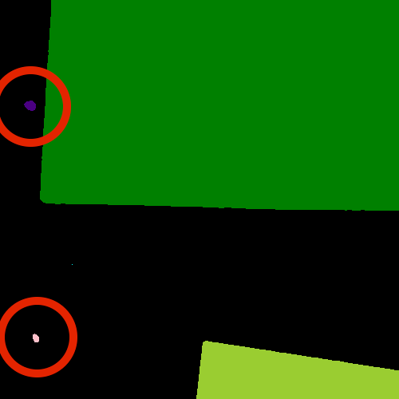

False positive objects

# Morphometrics

- Properties of the shape of an object.
- [skimage regionprops](https://scikit-image.org/docs/dev/api/skimage.measure.html#skimage.measure.regionprops)
- Basic e.g., area, perimeter, center
- More complex e.g., eccentricity, bounding box

# Capstone challenge

- Morphometrics for bacterial colonies.
- Brings together blurring, thresholding, and connected component analysis.

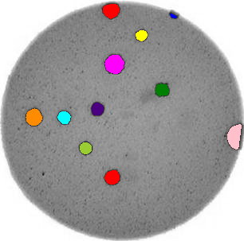

# Optional breakout 2

- What imaging tools are people in your field using?
- How does that fit in with an open source image processing stack?